# Tensorflow Project Exercise

Let's wrap up this Deep Learning by taking a a quick look at the effectiveness of Neural Nets!

We'll use the [Bank Authentication Data Set](https://archive.ics.uci.edu/ml/datasets/banknote+authentication) from the UCI repository.

The data consists of 5 columns:

- variance of Wavelet Transformed image (continuous)
- skewness of Wavelet Transformed image (continuous)
- curtosis of Wavelet Transformed image (continuous)
- entropy of image (continuous)
- class (integer)

Where class indicates whether or not a Bank Note was authentic.

This sort of task is perfectly suited for Neural Networks and Deep Learning! Just follow the instructions below to get started!

## Get the Data

** Use pandas to read in the bank_note_data.csv file **

```python
import pandas as pd
```

```python
data = pd.read_csv('bank_note_data.csv')
```

** Check the head of the Data **

```python
data.head()
```

|  | Image.Var | Image.Skew | Image.Curt | Entropy | Class |
| --- | --- | --- | --- | --- | --- |
| 0 | 3.62160 | 8.6661 | -2.8073 | -0.44699 | 0 |
| 1 | 4.54590 | 8.1674 | -2.4586 | -1.46210 | 0 |
| 2 | 3.86600 | -2.6383 | 1.9242 | 0.10645 | 0 |
| 3 | 3.45660 | 9.5228 | -4.0112 | -3.59440 | 0 |
| 4 | 0.32924 | -4.4552 | 4.5718 | -0.98880 | 0 |

## EDA

We'll just do a few quick plots of the data.

** Import seaborn and set matplolib inline for viewing **

```python
import seaborn as sns
%matplotlib inline
```

** Create a Countplot of the Classes (Authentic 1 vs Fake 0) **

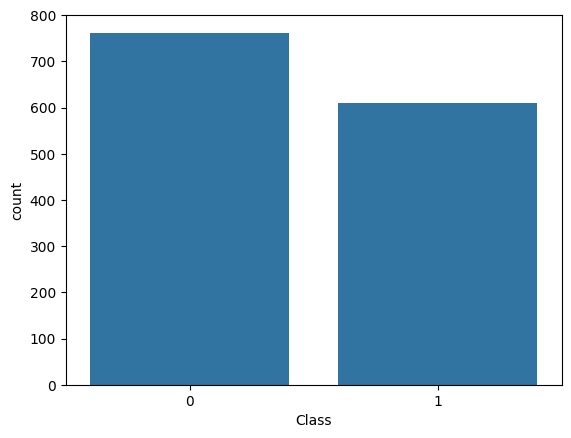

```python
sns.countplot(x='Class',data=data)
```

** Create a PairPlot of the Data with Seaborn, set Hue to Class **

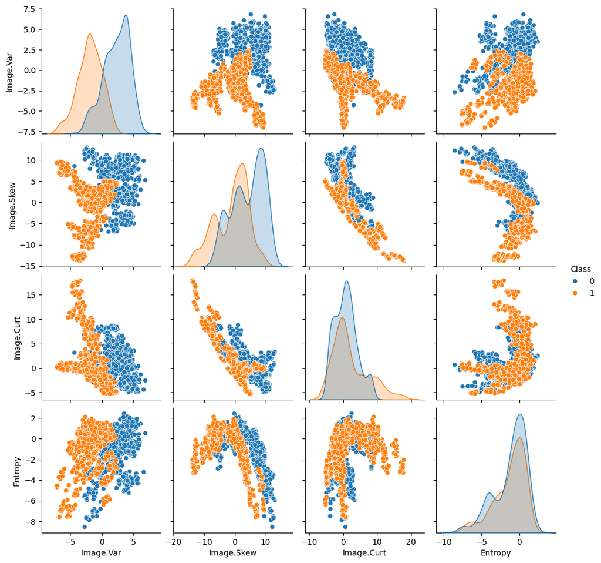

```python
sns.pairplot(data,hue='Class')
```

## Data Preparation

When using Neural Network and Deep Learning based systems, it is usually a good idea to Standardize your data, this step isn't actually necessary for our particular data set, but let's run through it for practice!

### Standard Scaling

```python
from sklearn.preprocessing import StandardScaler
```

**Create a StandardScaler() object called scaler.**

```python
scaler = StandardScaler()
```

**Fit scaler to the features.**

```python
scaler.fit(data.drop('Class',axis=1))
```

```
StandardScaler()
```

**Use the .transform() method to transform the features to a scaled version.**

```python
scaled_features = scaler.fit_transform(data.drop('Class',axis=1))
```

**Convert the scaled features to a dataframe and check the head of this dataframe to make sure the scaling worked.**

```python
df_feat = pd.DataFrame(scaled_features,columns=data.columns[:-1])
df_feat.head()
```

|  | Image.Var | Image.Skew | Image.Curt | Entropy |
| --- | --- | --- | --- | --- |
| 0 | 1.121806 | 1.149455 | -0.975970 | 0.354561 |
| 1 | 1.447066 | 1.064453 | -0.895036 | -0.128767 |
| 2 | 1.207810 | -0.777352 | 0.122218 | 0.618073 |
| 3 | 1.063742 | 1.295478 | -1.255397 | -1.144029 |
| 4 | -0.036772 | -1.087038 | 0.736730 | 0.096587 |

## Train Test Split

** Create two objects X and y which are the scaled feature values and labels respectively.**

```python
X = df_feat
```

```python
y = data['Class']
```

** Use SciKit Learn to create training and testing sets of the data as we've done in previous lectures:**

```python
from sklearn.model_selection import train_test_split
```

```python
X_train, X_test, y_train, y_test = train_test_split(X, y, test_size=0.3)
```

# Tensorflow

```python
import tensorflow as tf
```

```
WARNING:tensorflow:From C:\Users\msanh\anaconda3\Lib\site-packages\keras\src\losses.py:2976: The name tf.losses.sparse_softmax_cross_entropy is deprecated. Please use tf.compat.v1.losses.sparse_softmax_cross_entropy instead.
```

** Create a list of feature column objects using tf.feature.numeric_column() as we did in the lecture**

```python
df_feat.columns
```

```
Index(['Image.Var', 'Image.Skew', 'Image.Curt', 'Entropy'], dtype='object')
```

```python
image_var = tf.feature_column.numeric_column("Image.Var")
image_skew = tf.feature_column.numeric_column('Image.Skew')
image_curt = tf.feature_column.numeric_column('Image.Curt')
entropy =tf.feature_column.numeric_column('Entropy')
```

[output not shown]

```python
feat_cols = [image_var,image_skew,image_curt,entropy]
```

** Create an object called classifier which is a DNNClassifier from learn. Set it to have 2 classes and a [10,20,10] hidden unit layer structure:**

```python
classifier = tf.estimator.DNNClassifier(hidden_units=[10, 20, 10], n_classes=2,feature_columns=feat_cols)
```

[output not shown]

** Now create a tf.estimator.pandas_input_fn that takes in your X_train, y_train, batch_size and set shuffle=True. You can play around with the batch_size parameter if you want, but let's start by setting it to 20 since our data isn't very big. **

```python
def input_fn(X, y, batch_size=20, shuffle=True):
    dataset = tf.data.Dataset.from_tensor_slices((dict(X), y))

    if shuffle:
        dataset = dataset.shuffle(buffer_size=len(X))

    dataset = dataset.batch(batch_size)
    return dataset
```

```python
input_func = lambda: input_fn(X_train, y_train, batch_size=20, shuffle=True)
```

** Now train classifier to the input function. Use steps=500. You can play around with these values if you want!**

*Note: Ignore any warnings you get, they won't effect your output*

```python
classifier.train(input_fn=input_func,steps=500)
```

[output not shown]

## Model Evaluation

** Create another pandas_input_fn that takes in the X_test data for x. Remember this one won't need any y_test info since we will be using this for the network to create its own predictions. Set shuffle=False since we don't need to shuffle for predictions.**

```python
def inference_input_fn(X, batch_size=20, shuffle=False):
    dataset = tf.data.Dataset.from_tensor_slices(dict(X))

    if shuffle:
        dataset = dataset.shuffle(buffer_size=len(X))

    dataset = dataset.batch(batch_size)
    return dataset
```

```python
pred_fn = lambda: inference_input_fn(X_test, batch_size=len(X_test), shuffle=False)
```

** Use the predict method from the classifier model to create predictions from X_test **

```python
note_predictions = list(classifier.predict(input_fn=pred_fn))
```

```python
note_predictions[0]
```

[output not shown]

```python
final_preds  = []
for pred in note_predictions:
    final_preds.append(pred['class_ids'][0])
```

** Now create a classification report and a Confusion Matrix. Does anything stand out to you?**

```python
from sklearn.metrics import classification_report,confusion_matrix
```

```python
print(confusion_matrix(y_test,final_preds))
```

[output not shown]

```python
print(classification_report(y_test,final_preds))
```

[output not shown]

## Optional Comparison

**Use SciKit Learn to Create a Random Forest Classifier and compare the confusion matrix and classification report to the DNN model**

```python
from sklearn.ensemble import RandomForestClassifier
```

```python
rfc = RandomForestClassifier(n_estimators=200)
```

```python
rfc.fit(X_train,y_train)
```

```python
rfc_preds = rfc.predict(X_test)
```

```python
print(classification_report(y_test,rfc_preds))
```

[output not shown]

```python
print(confusion_matrix(y_test,rfc_preds))
```

[output not shown]

# Export the Notebook as HTML

```python
from nbconvert import HTMLExporter
import nbformat
exporter = HTMLExporter()
notebook_path = 'Banknote-authentication-notebook.ipynb'
notebook = nbformat.read(notebook_path, as_version=4)
html_output, resources = exporter.from_notebook_node(notebook)
output_file = 'Banknote-authentication-notebook.html'
with open(output_file, 'w', encoding='utf-8') as f:
    f.write(html_output)
```